# Data Exploration

load and pre-process the data

```r
require('ellipse')
require('ggplot2')
require('reshape2')
source('~//Desktop//data//svn//programming//R//helpers//helpers.R')

data = read.csv('results/20140813-194306.csv',
                colClasses=c('numeric','factor','numeric','numeric','numeric',
                             'factor','numeric','numeric','numeric','numeric',
                             'numeric','numeric','numeric','numeric','numeric',
                             'numeric','character','character'))

ds = data[,c(1,4,7,8,11:16)] # only relevant data
dm = melt(ds,id.vars = c("Number.of.states", "Impairment")) # melted data

attach(ds)
```

plot all the relevant variables against each other

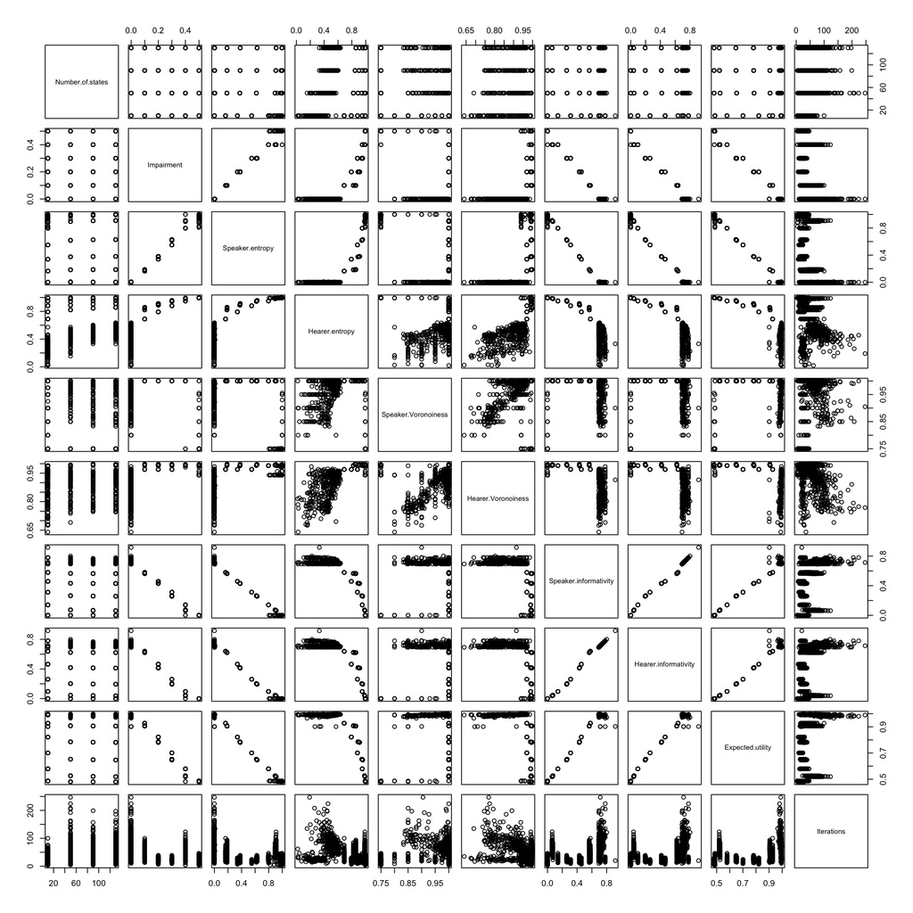

```r
pairs(~ Number.of.states + Impairment + Speaker.entropy + Hearer.entropy +
        Speaker.Voronoiness + Hearer.Voronoiness +
        Speaker.informativity + Hearer.informativity + Expected.utility + Iterations, data=ds)
```

some properties are very clearly positively correlated:

- speaker informativity, hearer informativity & expected utility
- impairment & speaker entropy

these two “clusters” are also strongly negatively correlated

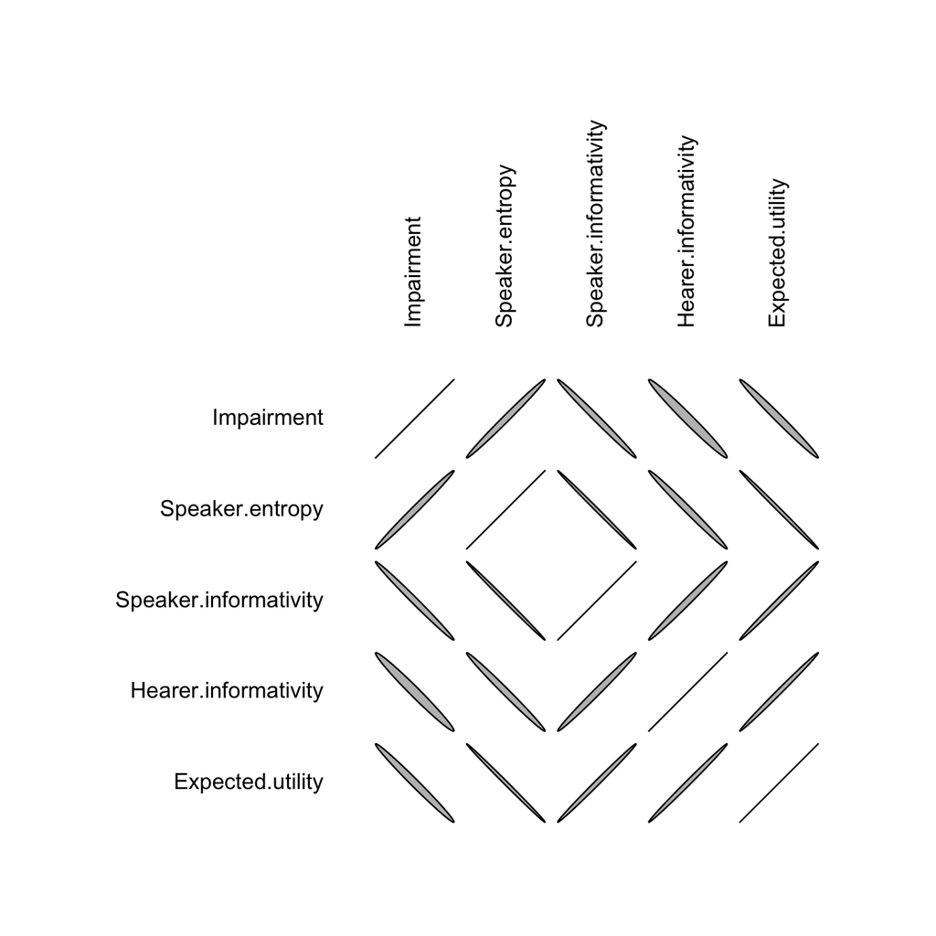

```r
dss = ds[,c(2,3,7,8,9)]

ctab <- cor(dss)

plotcorr(ctab)
```

## Replotting data for each combination of values of independent variables

We have two independent variables: impairment & number of states. The following plots show the means of all 100 data points for each combination of values for independent variables, together with the estimated confidence intervals.

We can exclude the informativity notions, because they are highly correlated with expected utility scores, and add no extra insight.

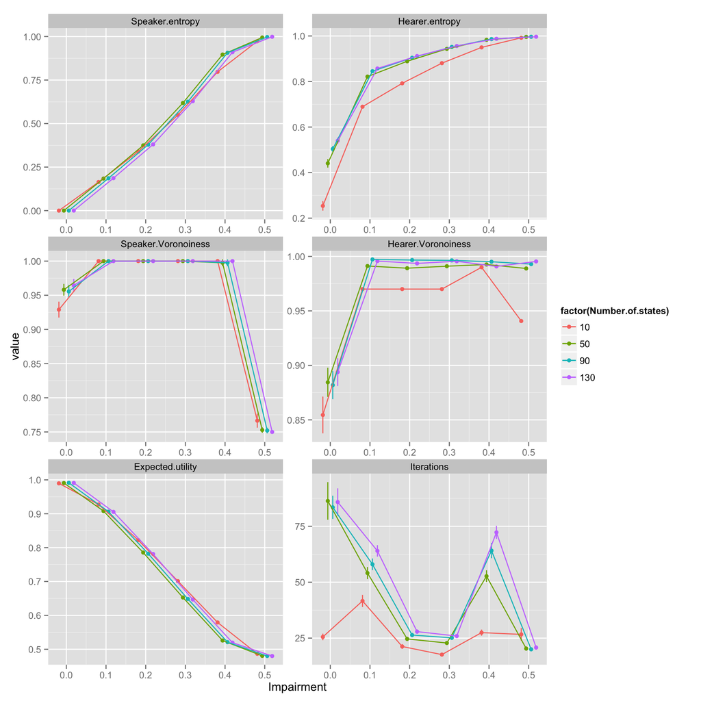

```r
dms = summarySE(dm, groupvars = c("Number.of.states", "Impairment", "variable"), measurevar="value")
dsub = subset(dms, !grepl("informativity",dms$variable) )

pd <- position_dodge(.05)
sp = ggplot(dsub, aes(x=Impairment, y=value, colour=factor(Number.of.states))) +
     geom_point(position = pd) +
     geom_errorbar(aes(ymin=value-ci, ymax=value+ci), width=0, position=pd) +
     geom_line(position=pd)

sp + facet_wrap(~ variable, ncol=2, scales="free")
```

We are particularly interested in the interplay between learning speed and EU. Generally, the fewer states, the faster we reach convergence (unsurprising). But speed to convergence also depends on the impairment value. For values 0.2, 0.3 and 0.5 we see a greatly reduced time to convergence. However, it is also clear that this increase in speed comes with a decline in expected utility. [Notice that the confidence intervals are very tight here, so that we can be sure that there is an almost functional realtionship between convergence speed and EU for each pair of independent parameter values.]

## Faster learning by impairment

we want to argue that (small?) levels of impairment can be helpful

unfortunately, impairment and EU are strongly negatively correlated;

however, impairment does seem to speed up learning;

- that’s different from Cailin’s stuff, because there learning speed could be argued to be only due to more balls being added per learning step

if learning is faster for some impairment, we should see these effects also in terms of higher EU at earlier stages - so we should look for stages before final convergence